# The Astmosphere that Compasses each Musical Genre

### Distribution of valence for each genre

Graphically we can see that jazz and classical are more left heavy meaning they are less positive. We can see that the mean for these genres lie more left skewed whereas the other genres are more normally distributed.

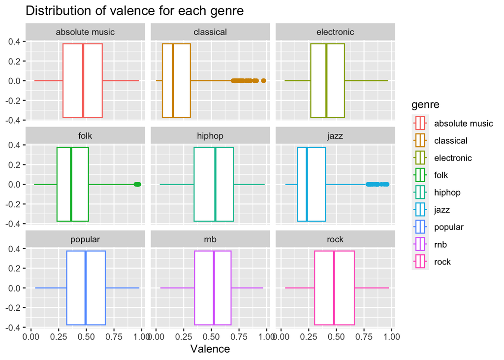

```r
plot2 = ggplot(spotsub, aes(valence,  color = genre)) +
  geom_boxplot() +facet_wrap(~genre) +
  labs(title = "Distribution of valence for each genre", x = "Valence");
plot2
```

## The relationship between Energy anad Valence for each Genre We can see that the relationship between Energy and Valence persists which each genre. When we look at the overall relationship between Energy and Valence it shows as the Energy increases the valance also increases.

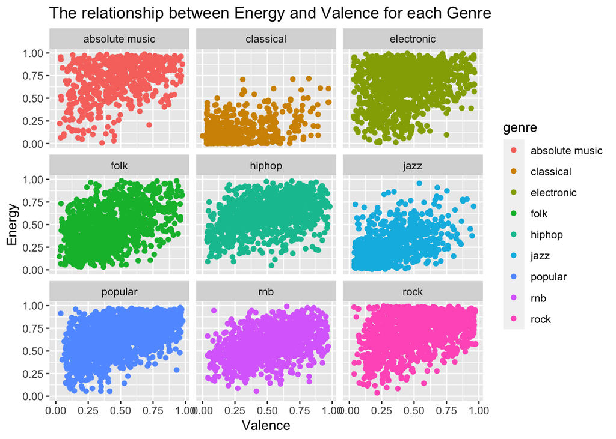

```r
plot3 = ggplot(spotsub, aes(x = valence, y = energy, color = genre)) +
  geom_point() + facet_wrap(~genre) +
  labs(title = "The relationship between Energy and Valence for each Genre", x = "Valence", y = "Energy");

plot3
```

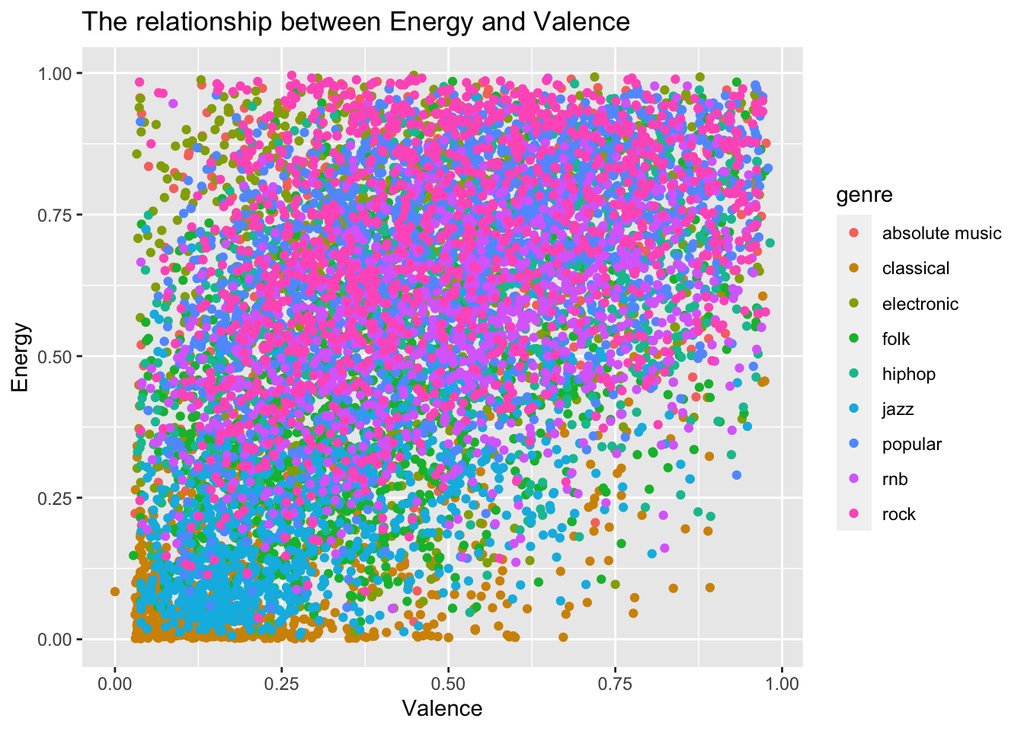

```r
plot4 = ggplot(spotsub, aes(x = valence, y = energy, color = genre)) +
  geom_point() +  labs(title = "The relationship between Energy and Valence", x = "Valence", y = "Energy");
plot4
```